# Passenger Traffic Forecasting at Keflavik Airport: A Time Series Analysis

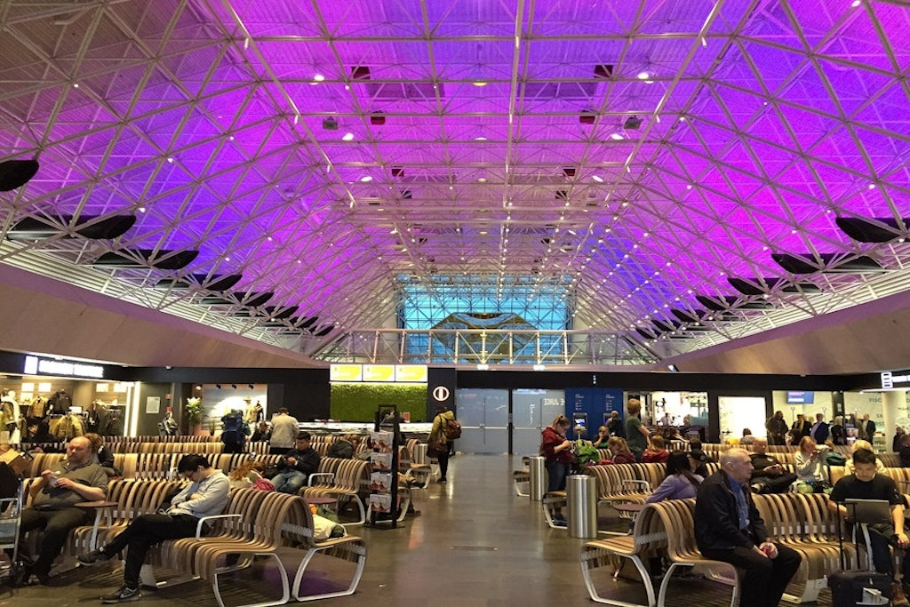

In this project, I conduct a time series analysis of the number of passengers passing through Keflavik Airport and attempt to fit a model that predicts the monthly number of passengers for data the model has not seen. The data for the number of passengers passing through Keflavik Airport was obtained from the Iceland Statistics Website: https://statice.is/statistics/business-sectors/tourism/passengers/.

# SARIMA Model

## 1 Get and clean data

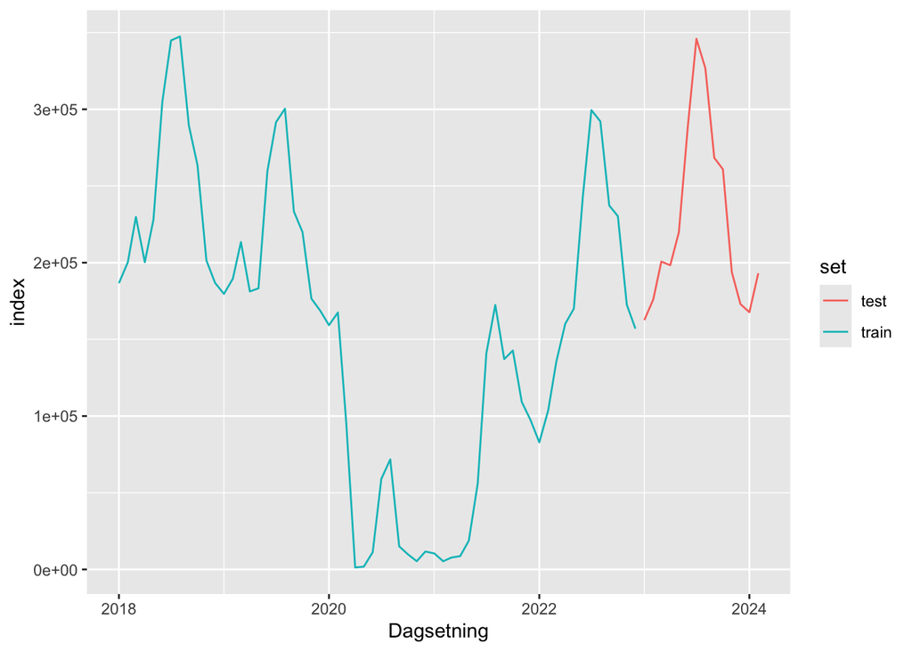

```r
data<-read.csv("fardegar.csv", sep = ";")

data$Dagsetning<- as.Date(paste0("01", data$Dagsetning), format = "%d%YM%m")## add 01 in front of each date, and make it a date variable.


## Create test and train data
train<-filter(data, Dagsetning <= "2022-12-01")
test<-filter(data,Dagsetning > "2022-12-01")


## plot our test and train sets
data$set <- ifelse(data$Dagsetning <= "2022-12-01", "train", "test")

ggplot(data,aes(Dagsetning, index, color= set))+ geom_line()
```

The plot shows the period we used to train our data and the period we used for prediction or testing our models.

## 2 Descriptive Statistics

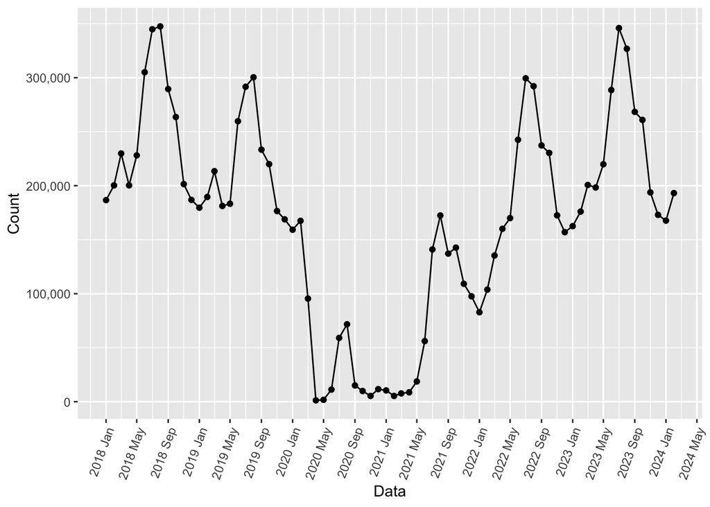

```r
# Find peak points
peak_points <- data[which(diff(sign(diff(data$index))) == -2) + 1, ]

ggplot(data, aes(x= Dagsetning, y = index)) + geom_point()+
                                              geom_line()+
                                              labs(x="Data", y = "Count")+
  scale_y_continuous(labels = comma) +scale_x_date(date_labels = "%Y %b", breaks = "4 months")+ theme(axis.text.x = element_text(angle = 70, hjust = 1))
```

From the picture, we see a clear seasonal pattern in the number of passengers at the airport. There are fewer passengers in the winter months, and the number increases in the summer, usually peaking around June, July, and August. We also observe a drop in the passenger count from March 2020 to July 2021. This decrease can obviously be attributed to the coronavirus pandemic. To further explore our data we will look at some tables.

```r
data%>%
  group_by(Year=year(Dagsetning))%>%

  summarize(Count = sum(index),
            Mean = mean(index),
            SD = sd(index),
            MIN = min(index),
            MIN_Month = month(Dagsetning, label = TRUE)[which.min(index)],
            Max = max(index),
            MAX_Month = month(Dagsetning, label = TRUE)[which.max(index)])%>%kable()
```

| Year | Count | Mean | SD | MIN | MIN_Month | Max | MAX_Month |
| --- | --- | --- | --- | --- | --- | --- | --- |
| 2018 | 2984018 | 248668.17 | 59875.55 | 186636 | Jan | 347475 | Aug |
| 2019 | 2597536 | 216461.33 | 45871.03 | 168850 | Dec | 300366 | Aug |
| 2020 | 609337 | 50778.08 | 60937.53 | 1262 | Apr | 167496 | Feb |
| 2021 | 907058 | 75588.17 | 64259.29 | 5339 | Feb | 172418 | Aug |
| 2022 | 2283435 | 190286.25 | 69814.20 | 82864 | Jan | 299473 | Jul |
| 2023 | 2814780 | 234565.00 | 62085.68 | 162554 | Jan | 345917 | Jul |
| 2024 | 360809 | 180404.50 | 17988.09 | 167685 | Jan | 193124 | Feb |

From the table, we observe that the year 2018 had the highest traffic at Keflavík Airport. There is also a noticeable decline in passenger numbers during the COVID-19 period from 2020 to 2021. In 2023, the count is approaching pre-pandemic levels. Additionally, January typically has lower passenger numbers, while August tends to have higher numbers, although this is not always the case

## 3 See if data is stationary

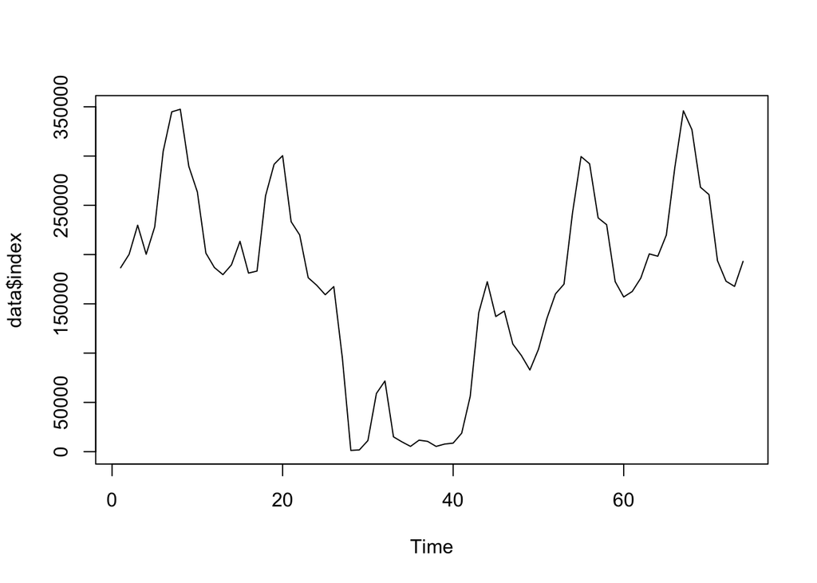

```r
ts.plot(data$index)
```

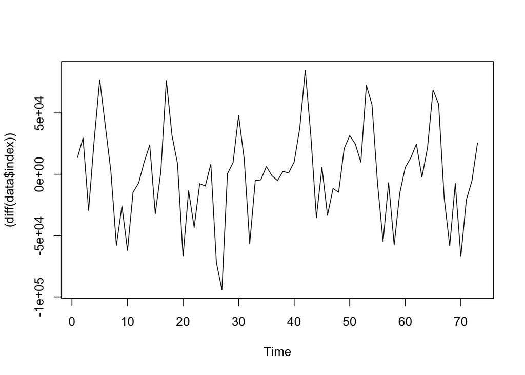

```r
ts.plot((diff(data$index)))
```

To make the data stationary, we need to differentiate the index variable.

### 3.1 Test for stationary

```r
## test for stationary
adf.test((data$index), alternative="stationary", k=0)
```

```
##
##  Augmented Dickey-Fuller Test
##
## data:  (data$index)
## Dickey-Fuller = -1.6452, Lag order = 0, p-value = 0.7201
## alternative hypothesis: stationary
```

```r
adf.test((diff(data$index)), alternative="stationary", k=0)
```

```
##
##  Augmented Dickey-Fuller Test
##
## data:  (diff(data$index))
## Dickey-Fuller = -5.513, Lag order = 0, p-value = 0.01
## alternative hypothesis: stationary
```

The adf.test confirms that the data must be differenced to be stationary.

## 4 ACF and PACF plots

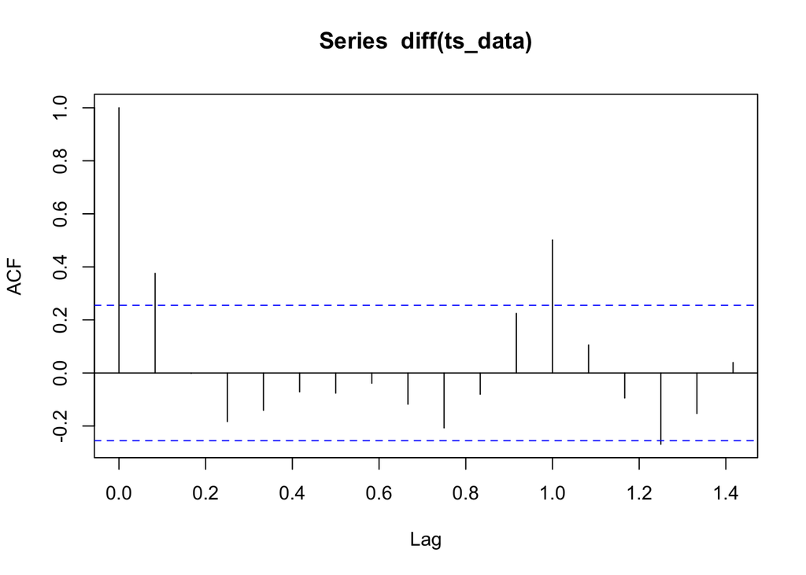

```r
## Create a time-series object from the train-date with a monthly frequency, starting from the earliest date from the train-dataþ
ts_data <- ts(train$index, frequency = 12, start = min(data$Dagsetning))

acf(diff(ts_data))
```

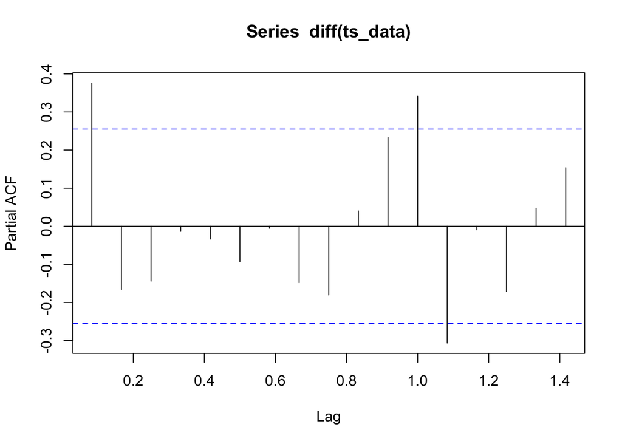

```r
pacf(diff(ts_data))
```

Our acf and pacf suggest using AR(1) and MA(0)

## 5 Create the model

```r
### use auto.arima to find optimal parameters according to AIC
auto.arima(ts_data)
```

```
## Series: ts_data
## ARIMA(1,1,0)(0,1,1)[12]
##
## Coefficients:
##          ar1     sma1
##       0.3800  -0.8322
## s.e.  0.1374   0.6822
##
## sigma^2 = 576747308:  log likelihood = -545.8
## AIC=1097.6   AICc=1098.16   BIC=1103.15
```

```r
## save the best model
arima_model <- auto.arima(ts_data)

## save fitted values
fitt<-fitted(arima_model)
## add fitted values to the train-set
train$fitted<-fitt
```

## 6 Forcast

Here we forecast the number of passengers passing through Keflavik Airport for future months that the model has not seen, or our test data.

```r
## forcast values for the next 14 months(our test-set)
forecast_values <- forecast(arima_model, h = 14)


## add the values to our test-set
test$pred<-forecast_values$mean
```

## 7 Model prediction errors.

We’ll use RMSE (Root Mean Squared Error) to see, on average, how much our predictions differ from the actual values

```r
# Residuals
errors<-test$index-test$pred

# Square the residuals
squared_errors <- errors^2

# Calculate the mean squared error
mse <- mean(squared_errors)

# Step 4: Calculate RMSE
rmse <- sqrt(mse)

# Print RMSE
print(rmse)
```

```
## [1] 57412.8
```

```r
test$diff<-test$index-test$pred

bla<-test$diff^2

mean<-mean(bla)
bla2<-sqrt(mean)
mean(test$diff)
```

```
## [1] 51923.72
```

```r
test %>%
  rename(Date = Dagsetning,
         Actual = index,
         Difference = diff,
         Predicted = pred)%>%gt()
```

| Date | Actual | Predicted | Difference |
| --- | --- | --- | --- |
| 2023-01-01 | 162554 | 145608.5 | 16945.47 |
| 2023-02-01 | 176036 | 154055.7 | 21980.35 |
| 2023-03-01 | 200693 | 157168.2 | 43524.80 |
| 2023-04-01 | 198333 | 133841.9 | 64491.09 |
| 2023-05-01 | 219827 | 143603.7 | 76223.29 |
| 2023-06-01 | 288593 | 197948.3 | 90644.66 |
| 2023-07-01 | 345917 | 251477.6 | 94439.36 |
| 2023-08-01 | 326782 | 260896.0 | 65886.01 |
| 2023-09-01 | 268355 | 207090.1 | 61264.93 |
| 2023-10-01 | 260912 | 198662.3 | 62249.65 |
| 2023-11-01 | 193788 | 158215.7 | 35572.31 |
| 2023-12-01 | 172990 | 149414.0 | 23576.02 |
| 2024-01-01 | 167685 | 140624.2 | 27060.85 |
| 2024-02-01 | 193124 | 150050.8 | 43073.22 |

From the table, we observe that our highest error occurred in July 2023, where the actual number of passengers was 345,917, but our prediction was 251,477. Conversely, our best prediction was for January 2023, where the actual number of passengers was 162,554, and we predicted 145,608.

```r
tidy_test <- gather(test, key = "variable", value = "value", pred, index)

plot1<-ggplot(tidy_test, aes(x = Dagsetning, y = value, color = variable)) +
  geom_line(data = subset(tidy_test, !(variable == "pred" & value == 0))) +
  labs(x="Date", y=" Number of passengers", title = "SARIMA", color= " ")
```

We can observe that the actual number of passengers passing through Keflavik Airport is consistently higher than our predicted number. Nevertheless, our model appears to effectively capture the seasonal variations in passenger numbers. However, from both the table and the plot, we observe that the difference between the actual and predicted values increases as the number of passengers passing through KEF airport increases. This suggests that our predictions become less accurate as the actual number of passengers rises

## 8 Residuals

To check if our model meets the assumption of normally distributed residuals, we first visually inspect the residuals. This allows us to see if they resemble a typical bell-shaped curve. After the plot, we use the Shapiro-Wilk test to confirm if our residuals are indeed normally distributed

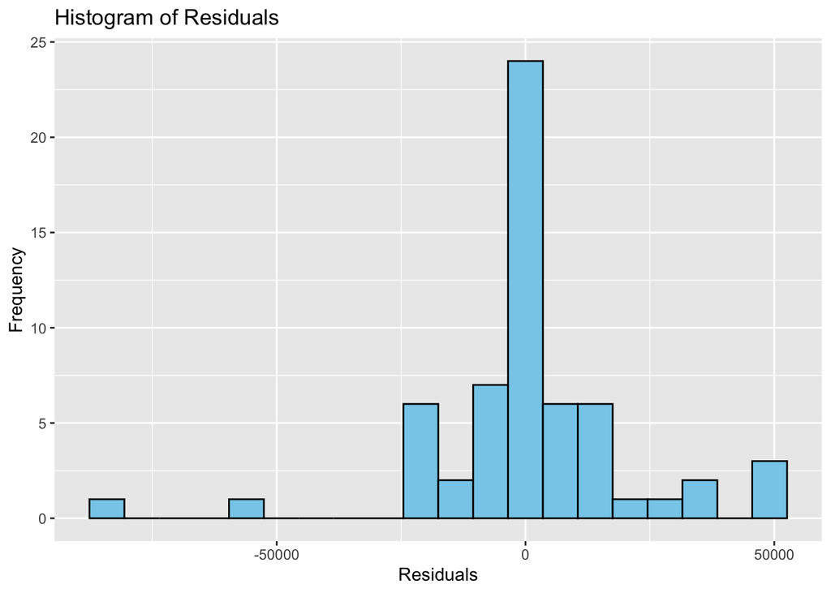

```r
# Extract residuals
residuals <- residuals(arima_model)

## Train rmse
train_rmse <- sqrt(mean(residuals^2))

# Create a data frame for plotting
residuals_df <- data.frame(Residuals = residuals)

# Plotting the residuals
ggplot(residuals_df, aes(x = Residuals)) +
  geom_histogram(bins = 20, fill = "skyblue", color = "black") +
  labs(title = "Histogram of Residuals",
       x = "Residuals",
       y = "Frequency")
```

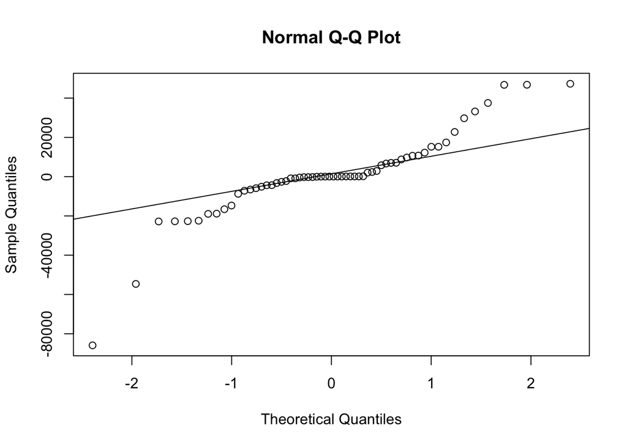

```r
qqnorm(residuals)
qqline(residuals)
```

The plots provide evidence suggesting that the residuals are not normally distributed. To further investigate, we apply the Shapiro-Wilk test.

```r
shapiro.test1<-shapiro.test(residuals)
print(shapiro.test1)
```

```
##
##  Shapiro-Wilk normality test
##
## data:  residuals
## W = 0.86182, p-value = 6.923e-06
```

The Shapiro-Wilk normality test results in a test statistic (W) of 0.86182 and a p-value of 6.923e-06. With such a small p-value, we reject the null hypothesis of normality, indicating that the residuals are not normally distributed.

# SARIMAX Model

## 1 Get and clean the covid data

```r
# Read the CSV file
covid <- read.csv("weekly_deaths.csv")

# Keep only the first two columns
covid <- covid[, c(1, 2)]

# Remove rows with missing values
covid <- na.omit(covid)

# Convert 'date' to Date format
covid$date <- as.Date(covid$date, format = "%Y-%m-%d")

# Extract month from 'date'
covid$Month <- format(covid$date, "%Y-%m")


# Calculate the sum of  rolling 7 day average of deaths for each month
covid<- covid %>%
  group_by(Month) %>%
  summarise(deaths = sum(World))

covid<-covid %>% rename(
  Dagsetning = Month
)

covid$Dagsetning <- as.Date(paste0(covid$Dagsetning, "-01"), format = "%Y-%m-%d")
data2<-merge(data,covid, by="Dagsetning", all.x = TRUE)
data2$deaths[is.na(data2$deaths)] <- 0
```

### 1.1 Create the test and train data

```r
train2<-filter(data, Dagsetning <= "2022-12-01")
test2<-filter(data,Dagsetning > "2022-12-01")

test2<-merge(test2,covid,by= "Dagsetning", all.x=TRUE)
train2<-merge(train2,covid,by= "Dagsetning", all.x=TRUE)

## Set NA to 0
train2$deaths[is.na(train2$deaths)] <- 0
test2$deaths[is.na(test$deaths)] <- 0
```

## 2 Number of passengers and covid deaths

We look at the Correlation between number of passengers and sum of rolling 7 day average of deaths for each month

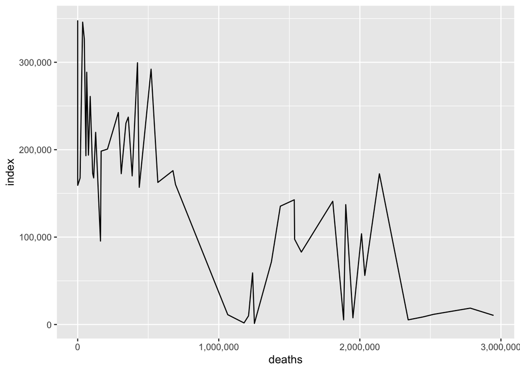

```r
ggplot(data2,aes(deaths,index))+ geom_line()+scale_x_continuous(labels = comma)+scale_y_continuous(labels = comma)
```

```r
corrilation<-cor(data2$deaths, data2$index)
print(corrilation)
```

```
## [1] -0.767186
```

We observe a correlation of -0.76 between deaths and the number of passengers, indicating a relationship between these variables. Additionally, from the plot, it is evident that there are fewer passengers when deaths are high. Therefore, it is reasonable to include the number of COVID deaths as an exogenous variable in the model.

## 3 New model SARIMAX mode

```r
deaths<-train2$deaths
ts_data2 <- ts(train2$index, frequency = 12, start = min(train2$Dagsetning))
sarimax_model<-auto.arima(ts_data2 , xreg = train2$deaths)
```

## 4 Errors

Here, we forecast the number of passengers passing through Keflavik Airport for future months that the model has not seen, or our test data, and then calculate the test error.

```r
## forcast values for the next 14 months(our test-set)
forecast_values2 <- forecast(sarimax_model, xreg = test2$deaths)


## add the values to our test-set
test2$pred<-forecast_values2$mean
```

```r
## model prediction errors.


# Residuals
errors<-test2$index-test2$pred

# Square the residuals
squared_errors <- errors^2

# Calculate the mean squared error
mse <- mean(squared_errors)

# Step 4: Calculate RMSE
rmse2 <- sqrt(mse)
```

```r
tidy_test2 <- gather(test2, key = "variable", value = "value", pred, index)

plot2<-ggplot(tidy_test2, aes(x = Dagsetning, y = value, color = variable)) +
  geom_line() +
  labs(x="Date",y=" Number of passengers", title = "SARIMAX", color= " ")
```

The SARIMAX model exhibits a similar issue to the SARIMA model, where the discrepancy between the actual and predicted values increases with a higher number of passengers passing through KEF airport. This indicates that as the number of passengers increases, the accuracy of our predictions diminishes.

## 5 Residuals

```r
# Extract residuals
residuals2 <- residuals(sarimax_model)

## Train rmse
train_rmse2 <- sqrt(mean(residuals2^2))

# Create a data frame for plotting
residuals_df2 <- data.frame(Residuals = residuals2)

# Plotting the residuals
residualplot2<-ggplot(residuals_df2, aes(x = Residuals)) +
  geom_histogram(bins = 20, fill = "skyblue", color = "black") +
  labs(title = "Histogram of Residuals",
       x = "Residuals",
       y = "Frequency")


shapiro.test2<-shapiro.test(residuals)
```

# Compairing Models

```r
comparison <- data.frame(
                   Model = c("SARIMA","SARIMAX"),
                   Test_errors = c(rmse, rmse2),
                   Train_errors = c(train_rmse,train_rmse2),
                   Normality_test = c(shapiro.test1$p.value,shapiro.test2$p.value))

kable(comparison)
```

| Model | Test_errors | Train_errors | Normality_test |
| --- | --- | --- | --- |
| SARIMA | 57412.8 | 20798.09 | 6.9e-06 |
| SARIMAX | 56874.4 | 20542.96 | 6.9e-06 |

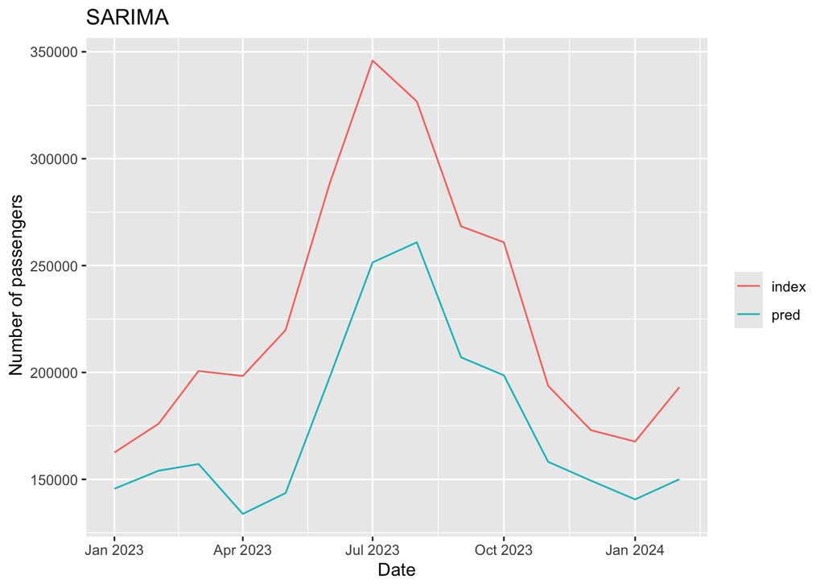

```r
plot1
```

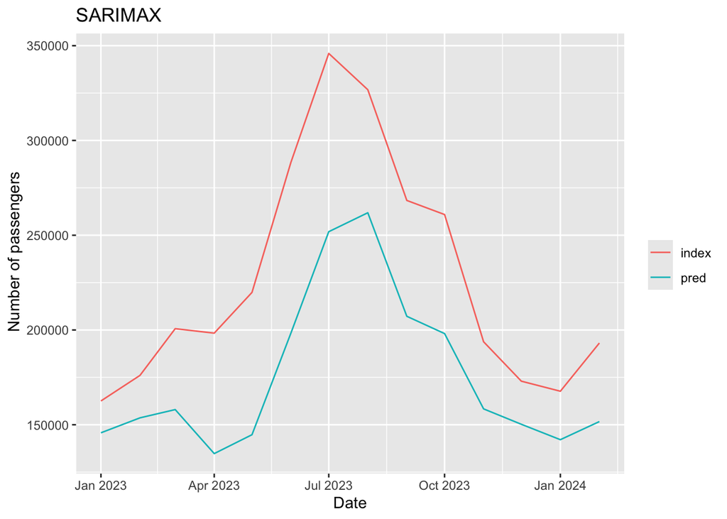

```r
plot2
```

lookin at the plots se see that the predictions are very similar for SARIMA and SARIMAX.

# Random Forest.

```r
data<-read.csv("data2.csv")


data$Dagsetning<-as.Date(data$Dagsetning)
data$Month <- as.numeric(format(data$Dagsetning, "%m"))
data$Year <- as.numeric(format(data$Dagsetning, "%Y"))
```

```r
# Split the data into training and testing sets

train <- data%>%filter(Dagsetning <= "2022-12-01")
test<- data%>%filter(Dagsetning > "2022-12-01")
```

## Tune RF

```
## mtry = 1  OOB error = 1621646737
## Searching left ...
## Searching right ...
## mtry = 2     OOB error = 1518971558
## 0.06331538 0.05
## mtry = 3     OOB error = 990554225
## 0.3478784 0.05
```

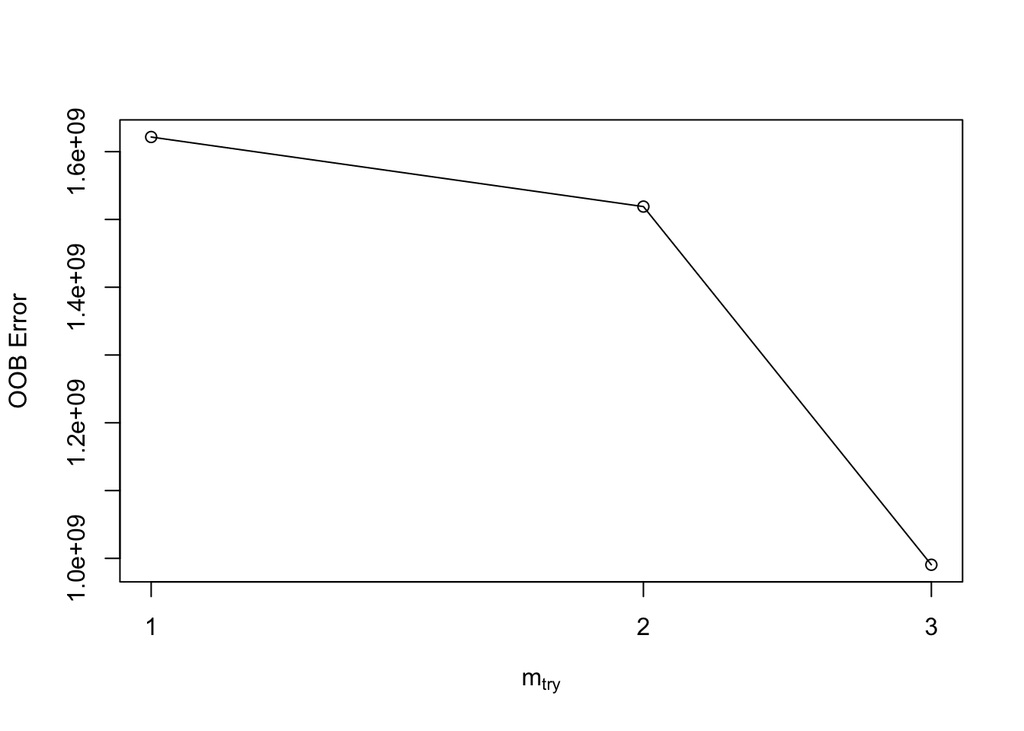

```r
## Model 2 where covid deaths are included


tuned_rf <- tuneRF(
  x = train[, -c(1,2)],  # Exclude the target variable
  y = train[, 2],   # Target variable
  improve = 0.05,
  trace = TRUE,
  plot = TRUE
)
```

We that 3 the is the best value for mtry in in the random forest 2 model.

## Built the model

```r
rf_model <- randomForest(index ~ Month + Year +deaths,  data = train,mtry = 2, ntree = 500)
rf_model2 <- randomForest(index ~ Month + Year +deaths,  data = train,mtry = 3, ntree = 500)
```

## errors

```r
# Make predictions on the test data
predictions <- predict(rf_model, newdata = test)
predictions2 <- predict(rf_model2, newdata = test)
test$predicted<-predictions
test$predicted2<-predictions2

# Make predictions on the train data
predictions <- predict(rf_model, newdata = train)
predictions2 <- predict(rf_model2, newdata = train)
train$predicted<-predictions
train$predicted2<-predictions2
```

```r
tidy_test <- gather(test, key = "variable", value = "value", predicted, index)
tidy_test2 <- gather(test, key = "variable", value = "value", predicted2, index)

rf1plot<-ggplot(tidy_test,aes(Dagsetning, value, color= variable))+ geom_line()+labs(x="Date",y=" Number of passengers", title = "RF1" , color= " ")
rf2plot<-ggplot(tidy_test2,aes(Dagsetning, value, color= variable))+ geom_line()+labs(x="Date",y=" Number of passengers", title = "RF2", color= " ")
```

## Errors

```r
## model prediction errors.


# Residuals
test_errors<-test$index-test$predicted

# Square the residuals
test_squared_errors <- test_errors^2

# Calculate the mean squared error
test_mse <- mean(test_squared_errors)

# Step 4: Calculate RMSE
rftest_rmse <- sqrt(test_mse)


# Extract residuals


## Train rmse
# Residuals
train_errors<-train$index-train$predicted

# Square the residuals
train_squared_errors <- train_errors^2

# Calculate the mean squared error
train_mse <- mean(train_squared_errors)

# Step 4: Calculate RMSE
rftrain_rmse <- sqrt(train_mse)


## model prediction errors.


# Residuals
test_errors2<-test$index-test$predicted2

# Square the residuals
test_squared_errors2 <- test_errors2^2

# Calculate the mean squared error
test_mse2 <- mean(test_squared_errors2)

# Step 4: Calculate RMSE
rftest_rmse2 <- sqrt(test_mse2)


# Extract residuals


## Train rmse
# Residuals
train_errors2<-train$index-train$predicted2

# Square the residuals
train_squared_errors2 <- train_errors2^2

# Calculate the mean squared error
train_mse2 <- mean(train_squared_errors2)

# Step 4: Calculate RMSE
rftrain_rmse2 <- sqrt(train_mse2)
```

## Compairing models

```r
comparison2 <- data.frame(
                   Model = c("SARIMA","SARIMAX","RF1","RF2"),
                   Test_errors = c(rmse, rmse2,rftest_rmse,rftest_rmse2),
                   Train_errors = c(train_rmse,train_rmse2,rftrain_rmse,rftrain_rmse2))

kable(comparison2)
```

| Model | Test_errors | Train_errors |
| --- | --- | --- |
| SARIMA | 57412.80 | 20798.09 |
| SARIMAX | 56874.40 | 20542.96 |
| RF1 | 44769.83 | 19541.96 |
| RF2 | 38830.78 | 16153.25 |

We observe that both our Random Forest models outperform the time series models, SARIMA and SARIMAX. The Random Forest models exhibit lower test errors compared to both the time series models, indicating superior predictive performance for future data.

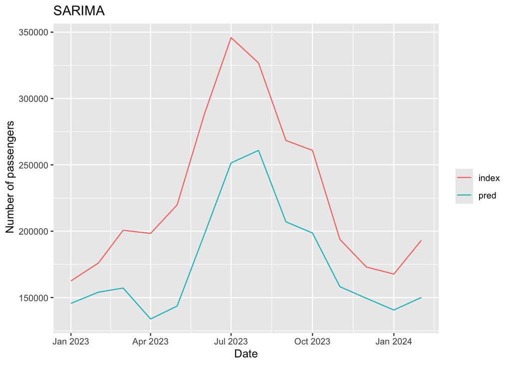

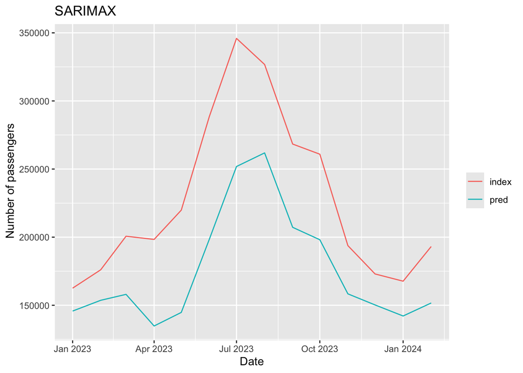

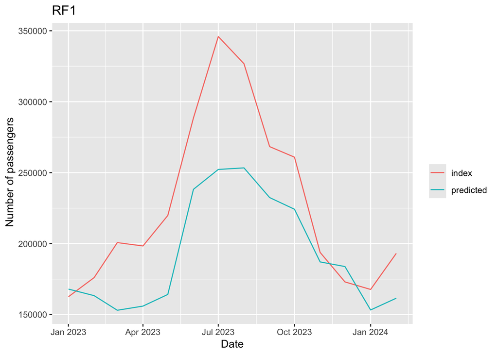

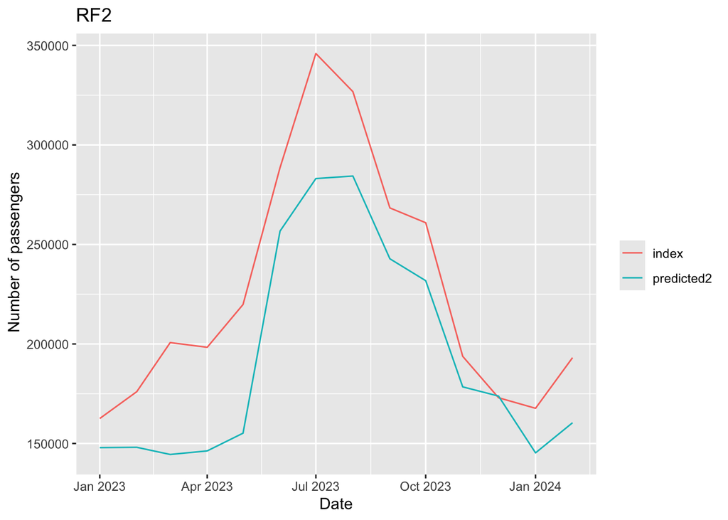

```r
plot1
plot2
rf1plot
rf2plot
```